# Primary cilia in *shroom3* mutants

David Kleinhans

16 Oktober 2017

# 1 **Rationale**

a ciliated *shrm3* wildtype pLLP

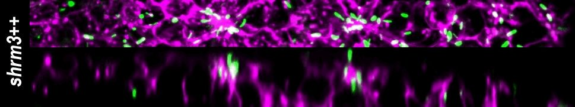

a ciliated *shrm3* mutant pLLP

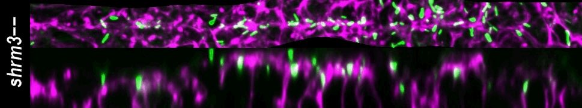

# 2 **Experiment setup**

## 2.1 Crossings

- **Stocknumber 120-1**
  - pairs: 6
  - transgenes: **cxcr4b(139):mCherry+/0** & **Tg($\beta$A:arl13b-eGFP)**
  - mutation: *shroom3*

## 2.2 Fixation

- 4% PFA
- o.n. @ 4°C

## 2.3 Mounting

- start: ~noon
- Mounting Protocol D.S. Kleinhans
- 0.5% low melt agarose
- stamp v1
- Two clutches (2x18 embryos)

## 2.4 Imaging

- **Objective**
  - 40X objective
- **Camera / Light**
  - Binning 1x1
  - Gain 4
- **ND**
  - 488/561 nm
  - Z spacing 0.4 µm

# 3 **Image processing**

## 3.1 Cilia Tracking

Primary Cilia posses different features that might be of interest in my study. What I want to know is how many cilia are there per Primordium and genotype and then maybe also where they are and how long they are. Quantification therefore has to take place in 3D. To quantify this I can think of two options, namely 3D object segmentation and ‘tracking’. Tracking might be a little contra intuitive since its mostly associated with tracking objects through time, but it can also be used to track objects through Z, if T and Z in the image properties are swapped. Since 3D object segmentation is quite time consuming I went for the tracking alternative, which is more straight forward. (Alternatively a neural network could be trained)

A short macro was written to prepare the data for analysis, it contains…

- cropping in X, Y and Z
- clearing of signal outside the pLLP
- swapping of T and Z

# 4 **Image Analysis**

## 4.1 TrackMate parameters

- Blob diameter: 1.5 µm
- Threshold: 20
- Tracker: simple LAP
- Initial search radius: 2 µm
- Search radius: 2 µm
- Max frame gap: 2 µm

## 4.2 Results

Tracks are shown in yellow

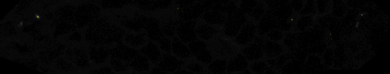

labeled Tracks

# 5 **Data Processing**

Data import

```r
setwd("D:/David/170105_SN120_shr3+Arl13b_fixed/Tracking/Tables")
filelist <- list.files(".", pattern="*wt", full.names=FALSE)
```

The import function was altered to count the Track_IDs per emrbyo

```r
library(plyr)
library(dplyr)
GT <- "++"
  read.data.all.count <- function(file){
    dat <- read.table(file, sep="\t", header=TRUE)
    dat$ID <- NULL
    dat$POSITION_Z <- NULL
    dat$RADIUS <- NULL
    dat$VISIBILITY <- NULL
    dat$MANUAL_COLOR <- NULL
    dat$Embryo <- file # add Emrbyo ID
    count <- ddply (.data=dat ,.variable=.(TRACK_ID),.fun=count)
    names(count)[2] <- "count"
    count$Embryo <- file # add Emrbyo ID
    count$GT <- GT # add Genotype
    return(count)
  }
SN120_Tracks_TRACKID_wt <- ldply(filelist, read.data.all.count)
```

Then the number (count) of the individual ‘Embryos’ was deduced (equal to number of Tracks)

```r
SN120_Tracks_count_wt <- ddply (.data=SN120_Tracks_TRACKID_wt ,.variable=.(Embryo, GT),.fun=count)
```

```r
SN120_Tracks_stats_mut <- ddply(SN120_Tracks_TRACKID_mut, .(Embryo), summarize, mean=mean(count, na.rm=TRUE), sd=sd(count, na.rm=TRUE), GT="--")
```

# 6 **Data Analysis**

## 6.1 Cilia count per Genotype

The two dataframes are bound together and the boxplot funtion is used

```r
SN120_Tracks_count <- rbind(SN120_Tracks_count_wt, SN120_Tracks_count_mut)
```

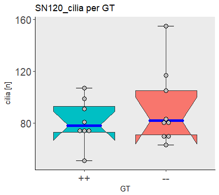

## 6.2 Cilia length per genotype

The two dataframes are bound together and the boxplot funtion is used

```r
SN120_Tracks_stats <- rbind(SN120_Tracks_stats_wt, SN120_Tracks_stats_mut)
```

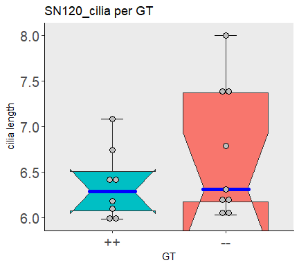

# 7 **Discussion**